# Hierarhical Models with Ternary Latent Variable

Youjin Lee

- Models
- three.1
- three.2
- three.3
- three.4
- three.5
- Summary

## Models

Most of the structure of likelihood is same as that in [hierarhical models with binary latent variable](http://htmlpreview.github.io/?https://github.com/neurodata/youjin/blob/master/report/latent_two.html) except that Bernoulli distributions now turn into Multinomial distributions. Models are based on [model 2] $P(A, X, Z) = P( A | Z) P(Z | X) P(X)$.

- Generate iid node attribute with a parameter $u = (u_{1}, u_{2})$

$X_{i} \overset{i.i.d}{\sim} Multinomial(u_{1}, u_{2}, 1 - u_{1} - u_{2} ), i = 1,... , n$

Note that $X$ should not be interpreted as a nominal, categorical variable since Euclidean distance was used to measure the distance of $X$.

- Generate latent variables conditional on $X$ as a function of $\omega$

$\begin{align} Z_{i} | X_{i} & \overset{i.i.d}{\sim} Multinomial( 1 ; \pi_{1}(X_{i}), \pi_{2}(X_{i}), \pi_{3}(X_{i}) ) = Multinomial(1; \pi_{k} = (1/3 + \omega) I(X_{i} = k ) + (2/3 - \omega ) I(X_{i} \neq k) /2 , k = 1,2,3 ) \\ & \overset{i.i.d}{\sim} \left\{ \begin{array}{cc} Multinomial(1; \color{red}{\frac{1}{3} + \omega}, \frac{2/3 - \omega}{2} , \frac{2/3 - \omega}{2} ) & X_{i} = 1 \\ Multinomial(1; \frac{2/3 - \omega}{2}, \color{red}{\frac{1}{3} + \omega} , \frac{2/3 - \omega}{2} ) & X_{i} = 2 \\ Multinomial(1; \frac{2/3 - \omega}{2}, \frac{2/3 - \omega}{2}, \color{red}{\frac{1}{3} + \omega} ) & X_{i} = 3 \end{array} \right. \end{align}$

- Generate local dependent graph : $\phi = (p_{k}, q_{k,l}; k,l = 1,... , K, k < l)$

$\begin{align} P_{\phi}(A = a | Z = z) & = \prod\limits_{k} P_{\phi}(A_{ij} = a_{ij} | Z = z) \times \prod\limits_{k < l} P_{\phi} (Y_{kl} = y_{kl} | Z = z) \\ & = \prod\limits_{Z_{i} = Z_{j} = 1}^{K} {p_{k}}^{a_{ij}}(1-p_{k})^{a_{ij}} \prod\limits_{Z_{i} \neq Z_{j}} {q_{kl}}^{a_{ij}}(1 - q_{kl})^{a_{ij}} \end{align}$

- Joint likelihood of $(A_{ij}, X_{i}, Z_{i} ; i,j=1,... ,n)$ under $A \perp X \big| Z$ can be represented as :

$P_{\theta}(A, X, Z) = P_{\phi}(A | Z) P_{\omega}(Z | X) P_{u}(X)$

### [sim] three.1

$X_{i} \overset{i.i.d}{\sim} Multinorm(1/3, 1/3, 1/3), i = 1, ... ,n.$

$Z_{i} | X_{i} = Z_{i} \overset{i.i.d}{\sim} Multinorm(1/3, 1/3, 1/3), i = 1,... , n.$

$A_{G} \sim Bern \left[ \begin{array}{c|c|c} \color{red}{0.5} & 0.1 & 0.1 \\ \hline 0.1 & \color{red}{0.5} & 0.1 \\ \hline 0.1 & 0.1 & \color{red}{0.5} \end{array} \right]$

| u1 | u2 | w | p1 | p2 | p3 | q12 | q13 | q12 |
| --- | --- | --- | --- | --- | --- | --- | --- | --- |
| 0.33 | 0.33 | 0 | 0.5 | 0.5 | 0.5 | 0.1 | 0.1 | 0.1 |

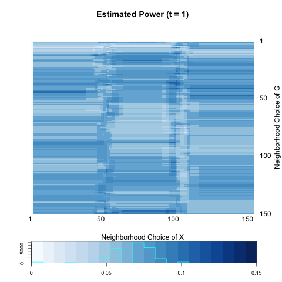

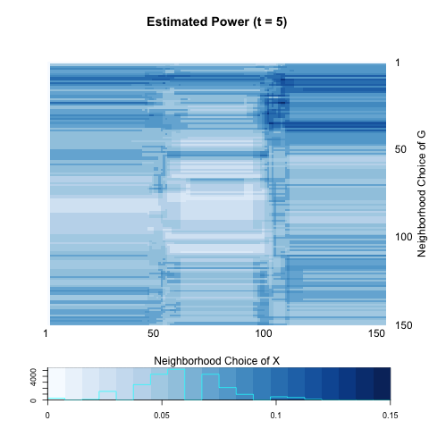

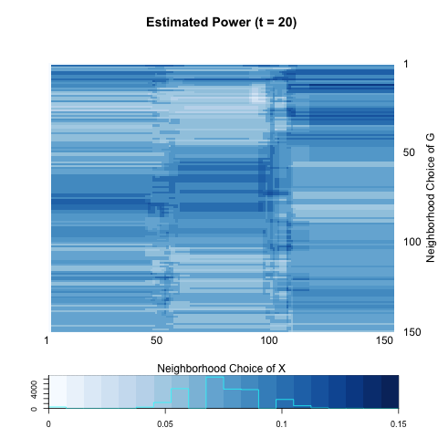

|  | t=1 | t=5 | t=20 |
| --- | --- | --- | --- |
| global test | 0.08 | 0.05 | 0.06 |
| local optimal | 0.11 | 0.14 | 0.13 |

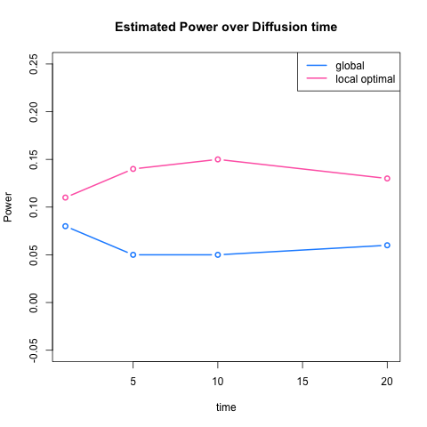

### [sim] three.2

$X_{i} \overset{i.i.d}{\sim} Multinorm(1/3, 1/3, 1/3), i = 1, ... ,n.$

$Z_{i} | X_{i} \overset{i.i.d}{\sim} \left\{ \begin{array}{cc} Multinorm(1/2, 1/4, 1/4) & X_{i} = 1 \\ Multinorm(1/4, 1/2, 1/4) & X_{i} = 2 \\ Multinorm(1/4, 1/4, 1/2) & X_{i} = 3 \end{array} \right.$

$A_{G} \sim Bern \left[ \begin{array}{c|c|c} \color{red}{0.5} & 0.1 & 0.1 \\ \hline 0.1 & \color{red}{0.5} & 0.1 \\ \hline 0.1 & 0.1 & \color{red}{0.5} \end{array} \right]$

| u1 | u2 | w | p1 | p2 | p3 | q12 | q13 | q23 |
| --- | --- | --- | --- | --- | --- | --- | --- | --- |
| 0.33 | 0.33 | 0.17 | 0.5 | 0.5 | 0.5 | 0.1 | 0.1 | 0.1 |

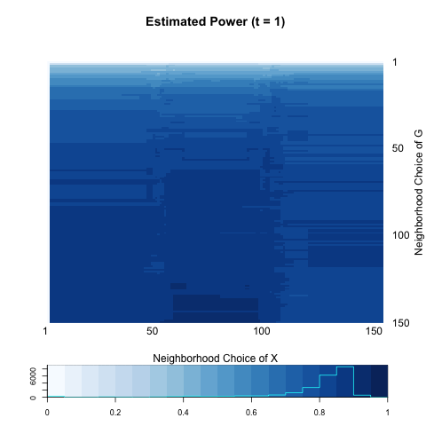

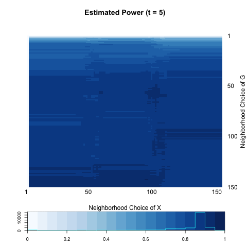

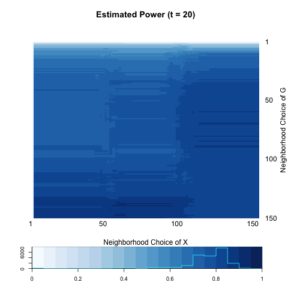

|  | t=1 | t=5 | t=20 |
| --- | --- | --- | --- |
| global test | 0.82 | 0.87 | 0.84 |
| local optimal | 0.93 | 0.96 | 0.92 |

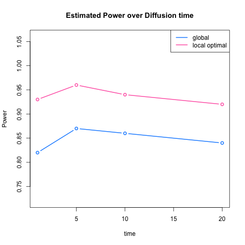

### [sim] three.3

$X_{i} \overset{i.i.d}{\sim} Multinorm(1/3, 1/3, 1/3), i = 1, ... ,n.$

$Z_{i} | X_{i} \overset{i.i.d}{\sim} \left\{ \begin{array}{cc} Multinorm(1/2, 1/4, 1/4) & X_{i} = 1 \\ Multinorm(1/4, 1/2, 1/4) & X_{i} = 2 \\ Multinorm(1/4, 1/4, 1/2) & X_{i} = 3 \end{array} \right.$

$A_{G} \sim Bern \left[ \begin{array}{c|c|c} 0.3 & 0.3 & 0.3 \\ \hline 0.3 & 0.3 & 0.3 \\ \hline 0.3 & 0.3 & 0.3 \end{array} \right]$

| u1 | u2 | w | p1 | p2 | p3 | q12 | q13 | q23 |
| --- | --- | --- | --- | --- | --- | --- | --- | --- |
| 0.33 | 0.33 | 0.17 | 0.3 | 0.3 | 0.3 | 0.3 | 0.3 | 0.3 |

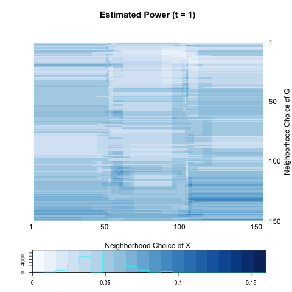

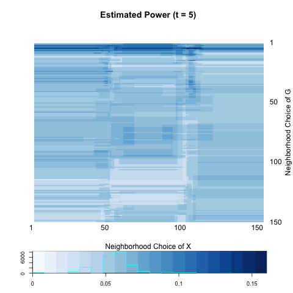

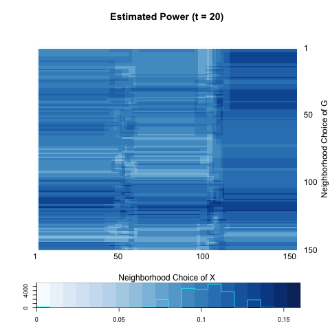

|  | t=1 | t=5 | t=20 |
| --- | --- | --- | --- |
| global test | 0.06 | 0.06 | 0.11 |
| local optimal | 0.09 | 0.16 | 0.14 |

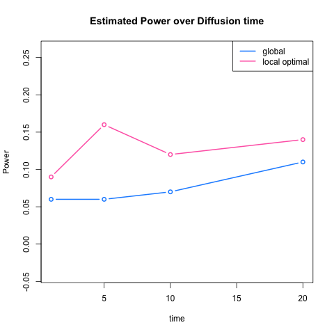

### [sim] three.4

$X_{i} \overset{i.i.d}{\sim} Multinorm(1/3, 1/3, 1/3), i = 1, ... ,n.$

$Z_{i} | X_{i} \overset{i.i.d}{\sim} \left\{ \begin{array}{cc} Multinorm(1/2, 1/4, 1/4) & X_{i} = 1 \\ Multinorm(1/4, 1/2, 1/4) & X_{i} = 2 \\ Multinorm(1/4, 1/4, 1/2) & X_{i} = 3 \end{array} \right.$

$A_{G} \sim Bern \left[ \begin{array}{c|c|c} \color{red}{0.5} & 0.1 & 0.1 \\ \hline 0.1 & \color{red}{0.5} & 0.1 \\ \hline 0.1 & 0.1 & 0.1 \end{array} \right]$

| u1 | u2 | w | p1 | p2 | p3 | q12 | q13 | q23 |
| --- | --- | --- | --- | --- | --- | --- | --- | --- |
| 0.33 | 0.33 | 0.17 | 0.5 | 0.5 | 0.1 | 0.1 | 0.1 | 0.1 |

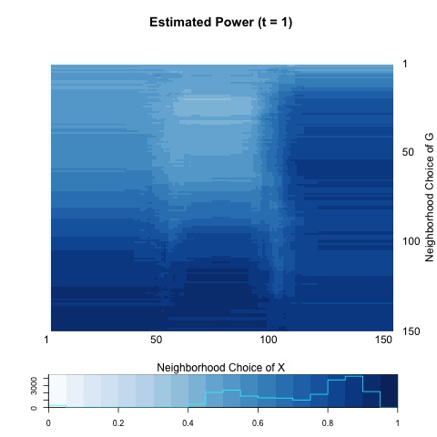

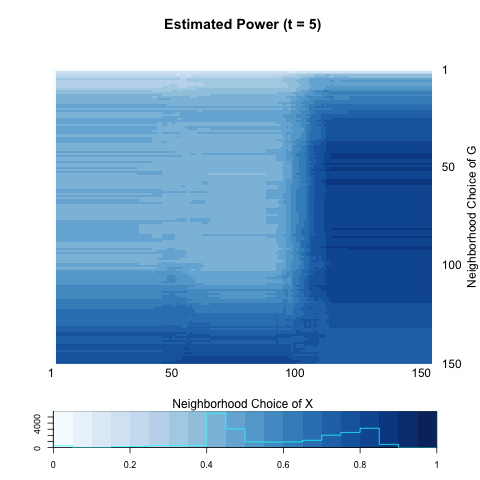

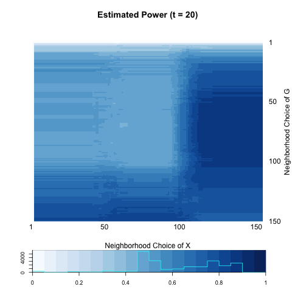

|  | t=1 | t=5 | t=20 |
| --- | --- | --- | --- |
| global test | 0.89 | 0.73 | 0.75 |
| local optimal | 0.93 | 0.87 | 0.89 |

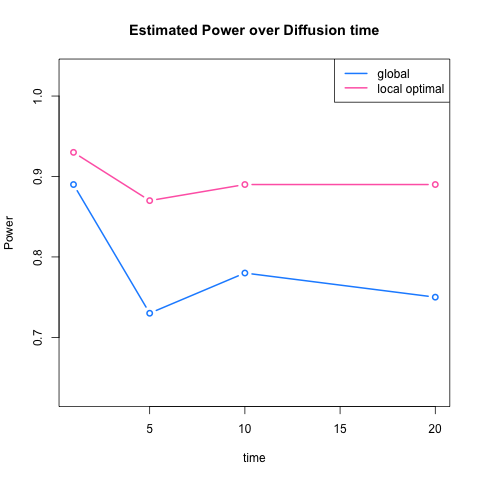

### [sim] three.5

$X_{i} \overset{i.i.d}{\sim} Multinorm(1/3, 1/3, 1/3), i = 1, ... ,n.$

$Z_{i} | X_{i} \overset{i.i.d}{\sim} \left\{ \begin{array}{cc} Multinorm(1/2, 1/4, 1/4) & X_{i} = 1 \\ Multinorm(1/4, 1/2, 1/4) & X_{i} = 2 \\ Multinorm(1/4, 1/4, 1/2) & X_{i} = 3 \end{array} \right.$

$A_{G} \sim Bern \left[ \begin{array}{c|c|c} \color{red}{0.5} & 0.1 & 0.1 \\ \hline 0.1 & 0.1 & 0.1 \\ \hline 0.1 & 0.1 & 0.1 \end{array} \right]$

| u1 | u2 | w | p1 | p2 | p3 | q12 | q13 | q23 |
| --- | --- | --- | --- | --- | --- | --- | --- | --- |
| 0.33 | 0.33 | 0.17 | 0.5 | 0.1 | 0.1 | 0.1 | 0.1 | 0.1 |

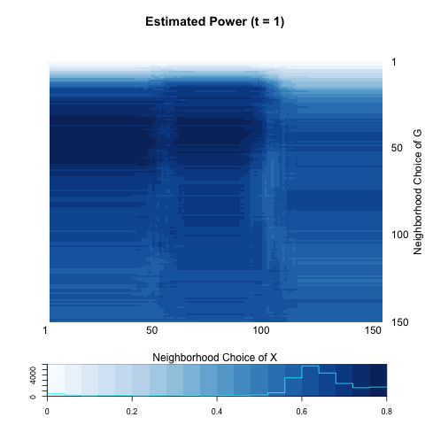

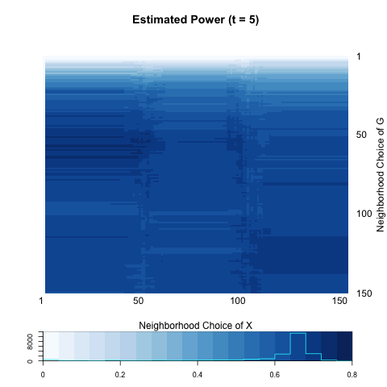

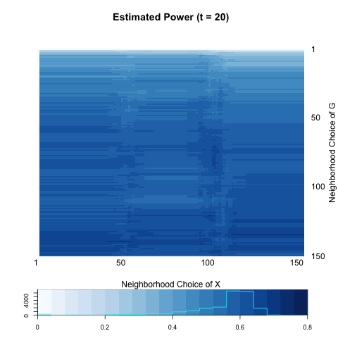

|  | t=1 | t=5 | t=20 |
| --- | --- | --- | --- |
| global test | 0.57 | 0.66 | 0.62 |
| local optimal | 0.80 | 0.75 | 0.71 |

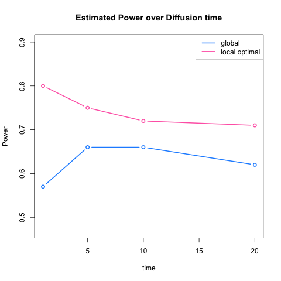

### [sim] three.6

$X_{i} \overset{i.i.d}{\sim} Multinorm(1/3, 1/3, 1/3), i = 1, ... ,n.$

$Z_{i} | X_{i} \overset{i.i.d}{\sim} \left\{ \begin{array}{cc} Multinorm(1/2, 1/4, 1/4) & X_{i} = 1 \\ Multinorm(1/4, 1/2, 1/4) & X_{i} = 2 \\ Multinorm(1/4, 1/4, 1/2) & X_{i} = 3 \end{array} \right.$

$A_{G} \sim Bern \left[ \begin{array}{c|c|c} \color{red}{0.5} & 0.1 & 0.1 \\ \hline 0.1 & 0.1 & 0.1 \\ \hline 0.1 & 0.1 & \color{red}{0.5} \end{array} \right]$

| u1 | u2 | w | p1 | p2 | p3 | q12 | q13 | q23 |
| --- | --- | --- | --- | --- | --- | --- | --- | --- |
| 0.33 | 0.33 | 0.17 | 0.5 | 0.1 | 0.5 | 0.1 | 0.1 | 0.1 |

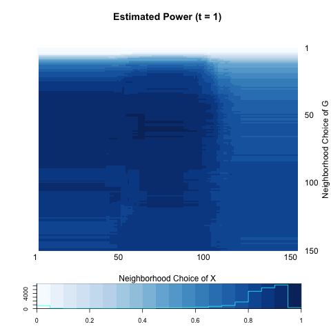

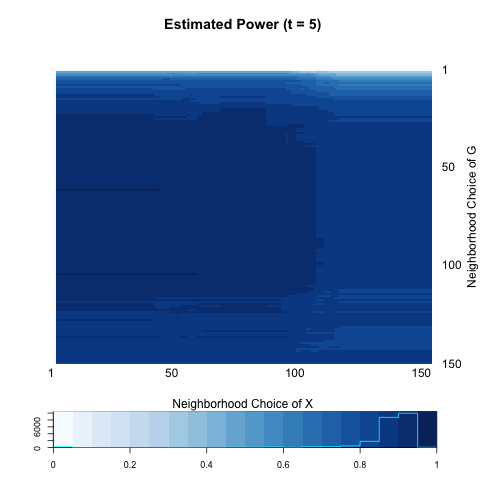

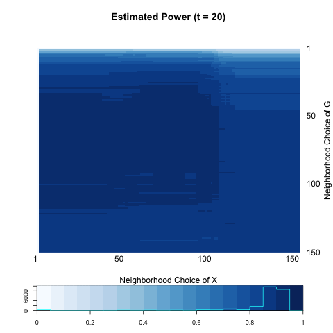

|  | t=1 | t=5 | t=20 |
| --- | --- | --- | --- |
| global test | 0.82 | 0.88 | 0.89 |
| local optimal | 0.98 | 0.96 | 0.95 |

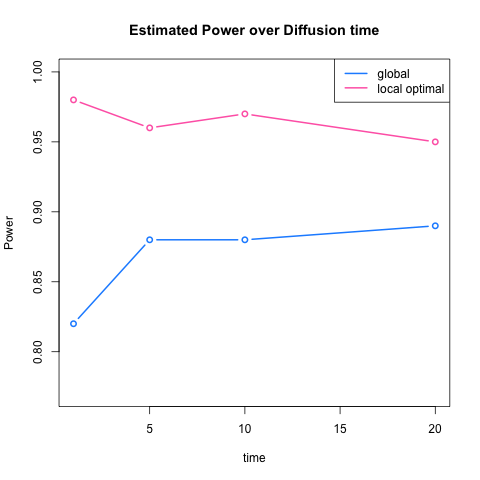

## Summary 1

$X_{i} \overset{i.i.d}{\sim} Multinorm(1/3, 1/3, 1/3), i = 1, ... ,n.$

$Z_{i} | X_{i} \overset{i.i.d}{\sim} \left\{ \begin{array}{cc} Multinorm(1/2, 1/4, 1/4) & X_{i} = 1 \\ Multinorm(1/4, 1/2, 1/4) & X_{i} = 2 \\ Multinorm(1/4, 1/4, 1/2) & X_{i} = 3 \end{array} \right.$

$A_{G} \sim Bern \left[ \begin{array}{c|c|c} \color{red}{p} & q & q \\ \hline q & \color{red}{p} & q \\ \hline q & q & \color{red}{p} \end{array} \right]$

### Power heatmaps

- Global Power

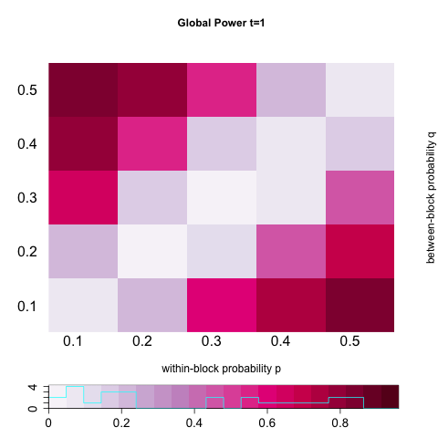

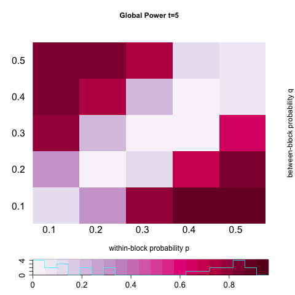

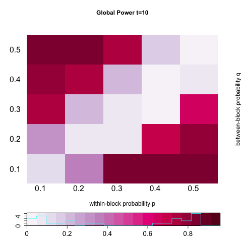

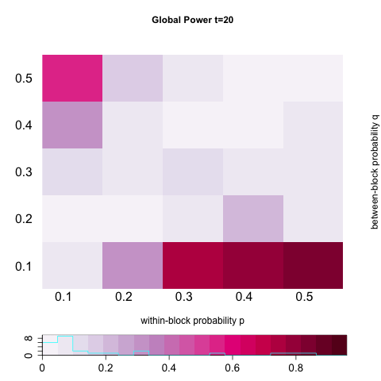

- Optimal Power

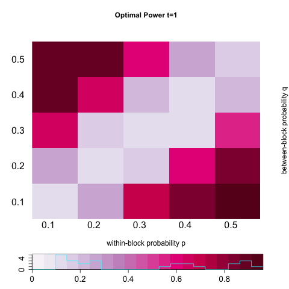

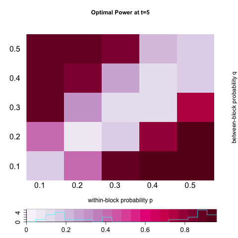

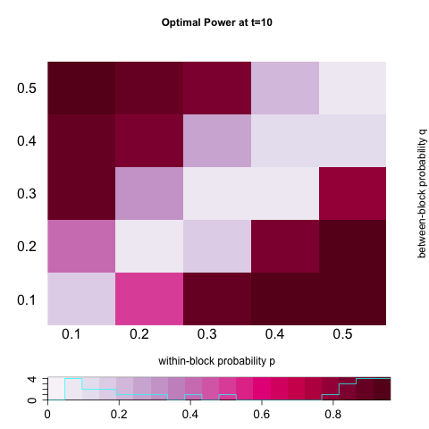

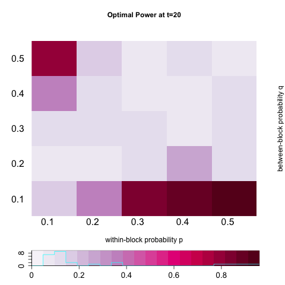